# Sea Surface Temperature (SST) Report

Project: STRETCH

Author: Dana K Briscoe

Report Date: 2026-10-24

### **Figure 1) Current SST, SSTA Conditions and Shipping Route Information.**

#### * The **red lines and solid icon represent the 2026 route and turtle release location on July 9, 2026**. The in situ SST measurement on that date was: 19°C.

#### * The **light blue ship icon and lines represent the 2025 route and turtle release location on July 8, 2025**. The in situ SST measurement on that date was: 19°C.

#### * For comparison, the **light green lines and solid icon represent the 2024 route and turtle release location on July 7, 2024**. The in situ SST measurement on that date was: 18°C.

#### * The **dark green lines and solid icon represent the 2023 route and turtle release location on July 10, 2023**. The in situ SST measurement on that date was: 24.8°C.

#### The 4 circles represent longitudes of interest across the eastern North Pacific Ocean. Figure 2 shows a time series of SST conditions at these 4 longitudes. Black lines represent the **18°C** isotherm. The Thermal Corridor area is outlined in white.

#### Current SST Conditions: 2026

[interactive chart not shown]

#### Current SST Anomalies: 2026

[interactive chart not shown]

#### Previous Year’s SST Anomalies: 2025

[interactive chart not shown]

### **Figure 2) Average SST time series.**

#### Weekly and long-term average sea surface temperatures at 4 longitudes in the eastern North Pacific:

#### * 43°N **160°W**

#### * 41°N **150°W**

#### * 40°N **145°W**

#### * 38°N **140°W**

#### For each longitude, the darker lines with circles represent the weekly SST average since 2025.

#### The lighter solid lines represent the long-term monthly mean SSTs at that location, between 1997-2022.

#### The black horizontal line at 18°C was used as a reference for optimal temperatures during turtle release.

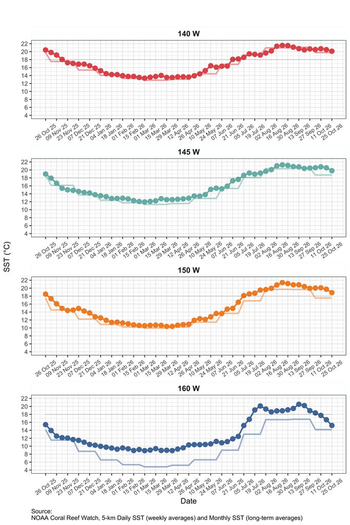

```
## [1] "publish date-time: 2026-10-24 10:08:06.168786 Pacific/Auckland"
```